# Part 2. Regularization

## Introdution to regularization

이번 시간에는 변수선택을 위한 방법으로서 회귀모형 기반의 regualrization 방법에 대해 소개드리도록 하겠습니다. 유전체 자료는 변수의 수가 표본을 수보다 많은 “small n, large p” 문제로 인해서 일반적인 least square estimation을 이용하는 회귀분석이 불가능합니다. 이를 위해, regularization procedure에서는 회귀모형에 penalty function을 추가하여 Y와의 연관성이 적은 회귀계수들을 축소시킵니다. 이는 통계적 추론보다는 예측이나 변수선택을 목적으로 하기 때문에, 목적에 맞도록 사용하는 것이 중요하겠습니다. 많은 연구자들을 통해서 다양한 penalty function들이 제안하였는데요. 그 중에서 대표적으로,

1. Ridge penalty
   $$\hat{\boldsymbol{\beta}} = \underset{\boldsymbol{\beta}}{\arg\min}{\left(\parallel Y-X\boldsymbol{\beta} \parallel ^2_2 + \lambda \parallel \boldsymbol{\beta} \parallel^2_2 \right) }$$
1. (장점) 변수 간 상관관계가 높은 경우에 분산이 커지는 현상을 방지함.
2. <단점> 아무리 높은 패널티를 주더라도 회귀계수 추정치가 0이 되지 않음(변수선택 불가능).
2. Lasso penalty (1996)
   $$\hat{\boldsymbol{\beta}}=\underset{\boldsymbol{\beta}}{\arg\min}\left(\parallel Y-X\boldsymbol{\beta} \parallel_2^2 + \lambda \parallel \boldsymbol{\beta} \parallel_1 \right)$$
1. (장점) 고차원 데이터에서 회귀모형 기반의 변수선택이 가능함.
2. <단점> 독립변수 간 상관관계가 높은 경우, 그 중 하나의 변수만 선택함(그룹 선택 불가능).
3. <단점> “small *n*, large *p*” 문제에서 최대 n개의 변수까지만 선택가능.
3. Elastic-net (2005)
   $$\hat{\boldsymbol{\beta}}=\underset{\beta}{\arg\min}\left(\parallel Y-X\boldsymbol{\beta} \parallel_2^2 + \lambda[ (1-\alpha) \parallel \boldsymbol{\beta} \parallel_2^2/2 + \alpha \parallel \boldsymbol{\beta} \parallel_1 ] \right)$$
1. (장점) Ridge와 Lasso 패널티의 단점을 보완하여, 독립변수 간 상관관계가 높은 경우에도 변수선택이 가능함.
2. <단점> 두 개의 tuning parameter ($\lambda \text{ and } \boldsymbol{\alpha}$) 선택이 어려움.
4. Group lasso (2007)
   $$\hat{\boldsymbol{\beta}}=\underset{\beta}{\arg\min} \left( \frac{1}{2}\parallel Y-\sum_{\ell=1}^{L} X_\ell\boldsymbol{\beta_\ell} \parallel_2^2 + \lambda \sum_{\ell=1}^{L}\sqrt{p_\ell} \parallel \boldsymbol{\beta_\ell} \parallel_2 \right)$$
- Group selection을 위함.
5. Sparse group lasso (2011)
   $$\hat{\boldsymbol{\beta}}=\underset{\beta}{\arg\min}\left( \frac{1}{2}\parallel Y-\sum_{\ell=1}^{L}X_\ell\boldsymbol{\beta_\ell} \parallel_2^2 + \lambda[ (1-\alpha) \sum_{\ell=1}^{L}\sqrt{p_\ell}\parallel \boldsymbol{\beta_\ell} \parallel_2 + \alpha \parallel \boldsymbol{\beta} \parallel_1 ] \right)$$
- Group selection을 하되 유의하지 않은 변수는 제외하도록.
6. etc…

여러 regularization 방법들 중에서 이번 시간에는 lasso와 elastic-net을 R package “glmnet”을 통해 배워보도록 하겠습니다.

먼저 다음 나올 plot, print, coef, predict 네 가지 함수는 R의 기본함수가 아니라 정식명칭은 plot.glmnet, print.glmnet, coef.glmnet, predict.glmnet이고, glmnet 적합 결과에 대해서만 축약하여 사용가능한 것입니다. 그래서 혹시 manual을 찾아보고 싶으시다면 help(plot.glmnet)을 이용하시면 되겠습니다.

y축은 회귀계수이고, x축은 회귀계수들의 L1norm으로 회귀계수들에 절대값을 취한뒤 합한 값입니다. 즉, L1norm이 작아진다는 것은 lambda값이 커진다는 것이기 때문에, x=0인 부분은 매우 큰 lambda 패널티가 부과된 결과라고 생각하시면 됩니다.

다음 xvar = “lambda” 입력값을 이용하시면 lambda x축에 대한 그림을 얻을 수 있지만 시각적인 부분이기때문에 아무거나 사용하셔도 무방합니다. plot(lasso.fit, xvar = “lambda”)

## Setup

### Importing the dataset and library

```r
library(qqman)
library(glmnet)

load("[Data]PNU-winter-workshop-2019.RData")

ls()
```

```
## [1] "imputed.data"  "workshop.data"
```

```r
str(workshop.data)
```

```
## List of 3
##  $ x  : num [1:370, 1:15000] 0 0 0 2 0 2 2 0 0 0 ...
##   ..- attr(*, "dimnames")=List of 2
##   .. ..$ : chr [1:370] "EE2.001" "EE2.002" "EE2.003" "EE2.004" ...
##   .. ..$ : chr [1:15000] "AX.90435719" "AX.90432064" "AX.90454689" "AX.90332566" ...
##  $ y  : num [1:370] 42524 38847 45518 47033 47202 ...
##  $ ref:'data.frame': 15000 obs. of  3 variables:
##   ..$ rs   : chr [1:15000] "AX-90435719" "AX-90432064" "AX-90454689" "AX-90332566" ...
##   ..$ chrom: int [1:15000] 6 1 10 1 2 20 2 6 18 3 ...
##   ..$ pos  : int [1:15000] 19444456 342857 50203642 13870972 8404704 482799 37517658 45029861 34199727 31138623 ...
```

```r
attach(workshop.data)
```

### Description of sequencing data

```r
str(x)
```

```
##  num [1:370, 1:15000] 0 0 0 2 0 2 2 0 0 0 ...
##  - attr(*, "dimnames")=List of 2
##   ..$ : chr [1:370] "EE2.001" "EE2.002" "EE2.003" "EE2.004" ...
##   ..$ : chr [1:15000] "AX.90435719" "AX.90432064" "AX.90454689" "AX.90332566" ...
```

```r
str(y)
```

```
##  num [1:370] 42524 38847 45518 47033 47202 ...
```

```r
str(ref)
```

```
## 'data.frame':    15000 obs. of  3 variables:
##  $ rs   : chr  "AX-90435719" "AX-90432064" "AX-90454689" "AX-90332566" ...
##  $ chrom: int  6 1 10 1 2 20 2 6 18 3 ...
##  $ pos  : int  19444456 342857 50203642 13870972 8404704 482799 37517658 45029861 34199727 31138623 ...
```

### Composition of glmnet

```r
ls("package:glmnet")
```

```
##  [1] "auc"                 "auc.mat"             "check_dots"
##  [4] "coef.cv.glmnet"      "coef.glmnet"         "coefnorm"
##  [7] "coxnet"              "coxnet.deviance"     "cv.coxnet"
## [10] "cv.elnet"            "cv.fishnet"          "cv.glmnet"
## [13] "cv.lognet"           "cv.mrelnet"          "cv.multnet"
## [16] "cvcompute"           "cvtype"              "deviance.glmnet"
## [19] "elnet"               "fishnet"             "getcoef"
## [22] "getcoef.multinomial" "getmin"              "glmnet"
## [25] "glmnet.control"      "glmnet_softmax"      "jerr"
## [28] "jerr.coxnet"         "jerr.elnet"          "jerr.fishnet"
## [31] "jerr.lognet"         "jerr.mrelnet"        "lambda.interp"
## [34] "lognet"              "mrelnet"             "na.mean"
## [37] "nonzeroCoef"         "plot.cv.glmnet"      "plot.glmnet"
## [40] "plot.mrelnet"        "plot.multnet"        "plotCoef"
## [43] "predict.coxnet"      "predict.cv.glmnet"   "predict.elnet"
## [46] "predict.fishnet"     "predict.glmnet"      "predict.lognet"
## [49] "predict.mrelnet"     "predict.multnet"     "print.glmnet"
## [52] "response.coxnet"     "rmult"
```

### Main functions

- glmnet

  ```
    glmnet(x, y,
       family=c("gaussian", "binomial", "poisson",
                "multinomial", "cox", "mgaussian"),
       alpha,
       nlambda,
       labmda,
       standardize=TRUE,
       penalty.factor,
       weights )
  ```

- cv.glmnet

  ```
    cv.glmnet(x, y,
     family=c("gaussian", "binomial", "poisson", "multinomial", "cox", "mgaussian"),
     alpha,
     type.measure=c("deviance", "mse", "auc"),
     nfolds=10,
     ...
     )
  ```

- coef
- predict
- plot
- See below for details,

  ```
  help(glmnet)
  vignette("glmnet_beta", package="glmnet")
  ```

## The Lasso

### Fitting the lasso model with alpha=1

```r
fit.lasso <- glmnet(x, y, alpha=1, nlambda=10, family="gaussian")
fit.lasso
```

```
##
## Call:  glmnet(x = x, y = y, family = "gaussian", alpha = 1, nlambda = 10)
##
##        Df   %Dev  Lambda
##  [1,]   0 0.0000 903.900
##  [2,]  13 0.1047 541.800
##  [3,]  84 0.4047 324.800
##  [4,] 180 0.6906 194.700
##  [5,] 252 0.8522 116.700
##  [6,] 310 0.9313  69.980
##  [7,] 349 0.9704  41.950
##  [8,] 386 0.9884  25.150
##  [9,] 407 0.9955  15.080
## [10,] 439 0.9983   9.039
```

- nlambda: recommended to be 100 or more.
- Df: the number of nonzero coefficients.
- %dev: the percent deviance explained (for gaussian, this is the R-square).
- Deviance: the difference of 2*log-likelihood between saturated model and current model.
- Lambda: the corresponding value of lambda.

### Solution path for lasso

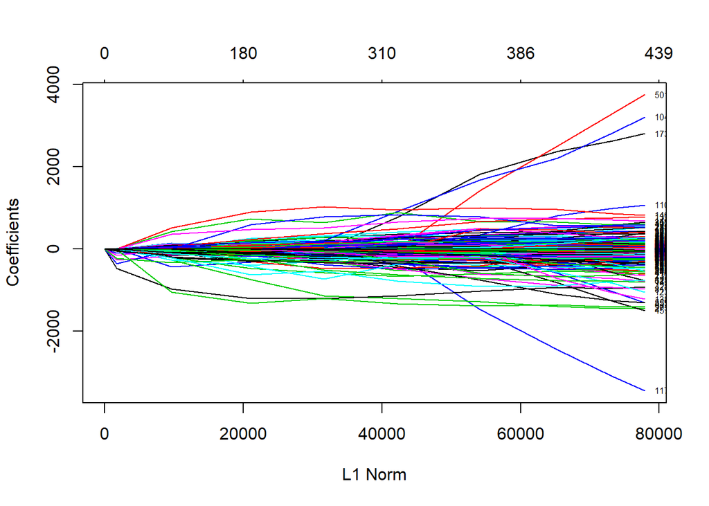

```r
  plot( fit.lasso, xvar="norm", label=TRUE )
```

### Getting coefficients for the lasso regression

#### Three functions which retrieve coefficients

```r
dim( fit.lasso$beta )
```

```
## [1] 15000    10
```

```r
head( fit.lasso$beta )
```

```
## 6 x 10 sparse Matrix of class "dgCMatrix"
```

```
##    [[ suppressing 10 column names 's0', 's1', 's2' ... ]]
```

```
##
## AX.90435719 . . . . . . . . . .
## AX.90432064 . . . . . . . . . .
## AX.90454689 . . . . . . . . . .
## AX.90332566 . . . . . . . . . .
## AX.90496155 . . . . . . . . . .
## AX.90443918 . . . . . . . . . .
```

### Getting coefficients for the lasso regression

```r
beta_coef <- coef( fit.lasso, s = fit.lasso$lambda[5] )
beta_pred <- predict( fit.lasso, type="coef", s = fit.lasso$lambda[5] )
```

### Comparison betwwen three approaches to get coefficients

```r
tmp <- c(33, 54, 192, 350, 361, 435)

data.frame(
  beta=fit.lasso$beta[tmp, 5],
  coef=beta_coef[tmp+1,],
  pred=beta_pred[tmp+1,]
)
```

```
##                    beta        coef        pred
## AX.90373344 -144.513722 -144.513722 -144.513722
## AX.90316606  -19.347762  -19.347762  -19.347762
## AX.90507036   -1.024381   -1.024381   -1.024381
## AX.90361043  -21.043062  -21.043062  -21.043062
## AX.90447851  -60.090700  -60.090700  -60.090700
## AX.90486253  -60.462772  -60.462772  -60.462772
```

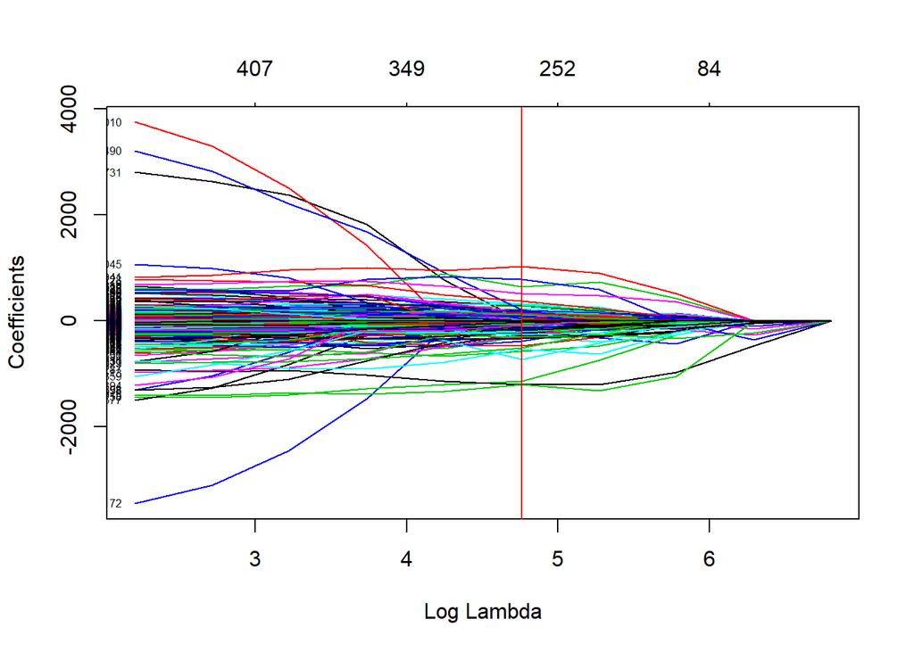

```r
plot(fit.lasso, xvar="lambda", label=TRUE)
abline(v=log(116.7), cex=2, col="red")
```

### Selecting the tuning parameter using cross-validation

```r
cv.lasso <- cv.glmnet(x, y, alpha=1, nlambda=100, family="gaussian", type.measure = "mse")
str(cv.lasso, max.level = 1)
```

```
## List of 10
##  $ lambda    : num [1:98] 904 863 824 786 750 ...
##  $ cvm       : num [1:98] 9947643 9912120 9877508 9834757 9787466 ...
##  $ cvsd      : num [1:98] 785362 784241 783094 780047 774707 ...
##  $ cvup      : num [1:98] 10733005 10696361 10660602 10614803 10562172 ...
##  $ cvlo      : num [1:98] 9162282 9127878 9094414 9054710 9012759 ...
##  $ nzero     : Named int [1:98] 0 2 2 3 3 3 5 7 8 9 ...
##   ..- attr(*, "names")= chr [1:98] "s0" "s1" "s2" "s3" ...
##  $ name      : Named chr "Mean-Squared Error"
##   ..- attr(*, "names")= chr "mse"
##  $ glmnet.fit:List of 12
##   ..- attr(*, "class")= chr [1:2] "elnet" "glmnet"
##  $ lambda.min: num 471
##  $ lambda.1se: num 904
##  - attr(*, "class")= chr "cv.glmnet"
```

### Plot for cv.glmnet

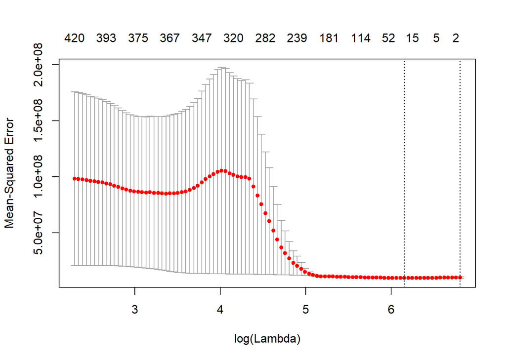

```r
plot(cv.lasso)
```

- lambda.min: the value which gives minumum mean cross-validated error (like “mse”).
- lambda.1se: the value which gives the most regularized model such that error is within one standard error of the minimum(lambda.1se).

```r
wh.1se <- min( which( cv.lasso$cvm < cv.lasso$cvup[which.min(cv.lasso$cvm)] ))
cv.lasso$lambda[ wh.1se ]
```

```
## [1] 903.8533
```

```r
cv.lasso$lambda.1se
```

```
## [1] 903.8533
```

```r
fit.lasso.min <- glmnet(x, y, alpha=1, family="gaussian", lambda=cv.lasso$lambda.min)
fit.lasso.1se <- glmnet(x, y, alpha=1, family="gaussian", lambda=cv.lasso$lambda.1se)

fit.lasso.min
```

```
##
## Call:  glmnet(x = x, y = y, family = "gaussian", alpha = 1, lambda = cv.lasso$lambda.min)
##
##      Df   %Dev Lambda
## [1,] 29 0.1694  471.3
```

```r
fit.lasso.1se
```

```
##
## Call:  glmnet(x = x, y = y, family = "gaussian", alpha = 1, lambda = cv.lasso$lambda.1se)
##
##      Df      %Dev Lambda
## [1,]  1 9.567e-17  903.9
```

### Visualization in manhattan plot

```r
lasso.nonzero.min <- which( fit.lasso.min$beta != 0 )
str(lasso.nonzero.min)
```

```
##  int [1:29] 1366 1992 2762 4287 4848 5544 5548 5675 6456 6613 ...
```

```r
summary( lm(y~x[, 1]) )
```

```
##
## Call:
## lm(formula = y ~ x[, 1])
##
## Residuals:
##     Min      1Q  Median      3Q     Max
## -8183.5 -1930.5   405.2  2282.6  7763.5
##
## Coefficients:
##             Estimate Std. Error t value Pr(>|t|)
## (Intercept) 43055.04     224.18 192.052   <2e-16 ***
## x[, 1]         74.88     175.47   0.427     0.67
## ---
## Signif. codes:  0 '***' 0.001 '**' 0.01 '*' 0.05 '.' 0.1 ' ' 1
##
## Residual standard error: 3154 on 368 degrees of freedom
## Multiple R-squared:  0.0004946,  Adjusted R-squared:  -0.002221
## F-statistic: 0.1821 on 1 and 368 DF,  p-value: 0.6698
```

```r
lm.pvalue <- NULL
for( j in 1:ncol(x) ){
  lm.coef <- summary( lm(y~x[, j]) )$coef
  if( nrow(lm.coef)==2 ){
    lm.pvalue[j] <- lm.coef[2, 4]
  } else if ( nrow(lm.coef)==1 ){
    lm.pvalue[j] <- NA
  }
}
```

```r
str( lm.pvalue )
```

```
##  num [1:15000] 0.67 0.588 0.688 0.203 0.262 ...
```

```r
summary( lm.pvalue )
```

```
##    Min. 1st Qu.  Median    Mean 3rd Qu.    Max.    NA's
##  0.0000  0.0951  0.3462  0.3933  0.6619  1.0000     633
```

```r
na.lm.pvalue <- which(is.na(lm.pvalue))
table( x[, na.lm.pvalue[1]] )
```

```
##
##   0
## 370
```

```r
df.lm.pvalue <- data.frame( ref, p=lm.pvalue)
colnames(df.lm.pvalue) <- c("SNP", "CHR", "BP", "P")
list(ref=head(ref), df.lm.pvalue=head(df.lm.pvalue))
```

```
## $ref
##                 rs chrom      pos
## 47207  AX-90435719     6 19444456
## 84     AX-90432064     1   342857
## 86513  AX-90454689    10 50203642
## 2388   AX-90332566     1 13870972
## 10966  AX-90496155     2  8404704
## 161363 AX-90443918    20   482799
##
## $df.lm.pvalue
##                SNP CHR       BP          P
## 47207  AX-90435719   6 19444456 0.66981825
## 84     AX-90432064   1   342857 0.58762581
## 86513  AX-90454689  10 50203642 0.68812025
## 2388   AX-90332566   1 13870972 0.20327856
## 10966  AX-90496155   2  8404704 0.26238478
## 161363 AX-90443918  20   482799 0.05218934
```

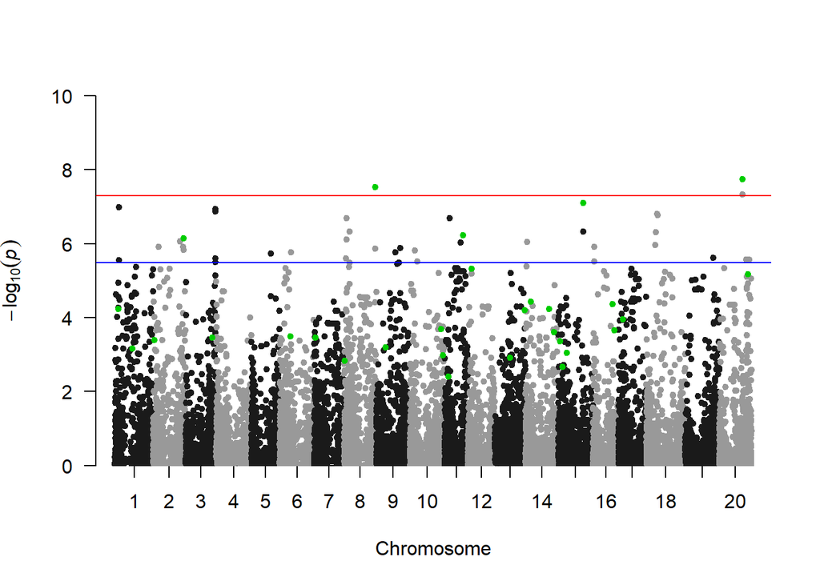

```r
bonferroni.cutoff <- 0.05/ncol(x)
qqman::manhattan(df.lm.pvalue, chr="CHR", bp="BP", p="P", snp="SNP", suggestiveline=-log10(bonferroni.cutoff),
                 highlight=df.lm.pvalue[lasso.nonzero.min,"SNP"], ylim=c(0,10))
```

### Prediction

```r
set.seed(20190130)
idx.train <- sample(nrow(x), 0.9*nrow(x))
idx.test <- (1:nrow(x))[-idx.train]
```

```r
cv.lasso.train <- cv.glmnet(x[idx.train,], y[idx.train], alpha=1, family="gaussian")
```

```r
fit.lasso.train.min <- glmnet(x[idx.train,], y[idx.train], alpha=1, family="gaussian", lambda=cv.lasso.train$lambda.min)
fit.lasso.train.1se <- glmnet(x[idx.train,], y[idx.train], alpha=1, family="gaussian", lambda=cv.lasso.train$lambda.1se)
```

```r
fit.lasso.train.min
```

```
##
## Call:  glmnet(x = x[idx.train, ], y = y[idx.train], family = "gaussian",      alpha = 1, lambda = cv.lasso.train$lambda.min)
##
##      Df    %Dev Lambda
## [1,]  5 0.06871  670.5
```

```r
fit.lasso.train.1se
```

```
##
## Call:  glmnet(x = x[idx.train, ], y = y[idx.train], family = "gaussian",      alpha = 1, lambda = cv.lasso.train$lambda.1se)
##
##      Df %Dev Lambda
## [1,]  0    0   1019
```

```r
newx <- x[idx.test, ]

newy.fit.min <- predict( fit.lasso.train.min, newx, type="response" )

head(
  data.frame(
    test.y=y[idx.test],
    fit.newy.min=as.numeric(newy.fit.min)
  )
)
```

```
##     test.y fit.newy.min
## 1 42908.20     43131.13
## 2 42897.82     42600.05
## 3 36763.64     43131.13
## 4 43530.82     43131.13
## 5 39341.26     43131.13
## 6 43512.29     43131.13
```

## Elastic-net with alpha$\in(0, 1)$

- Distinct advantages of elastic-net
- Grouping selection
- When n<<p, we can select variables up to **p**

### Generate binary response (y2)

```r
y2 <- ifelse( y > median(y), 1, 0 )

table(y2)
```

```
## y2
##   0   1
## 185 185
```

### Fitting elastic-net model

```r
fit.enet <- glmnet(x, y2, alpha=0.5, nlambda=10, family="binomial")
fit.enet
```

```
##
## Call:  glmnet(x = x, y = y2, family = "binomial", alpha = 0.5, nlambda = 10)
##
##        Df      %Dev   Lambda
##  [1,]   0 7.528e-15 0.268100
##  [2,]  27 7.385e-02 0.160700
##  [3,] 119 3.403e-01 0.096360
##  [4,] 230 5.844e-01 0.057760
##  [5,] 300 7.473e-01 0.034630
##  [6,] 358 8.468e-01 0.020760
##  [7,] 411 9.076e-01 0.012440
##  [8,] 447 9.443e-01 0.007460
##  [9,] 476 9.664e-01 0.004472
## [10,] 512 9.797e-01 0.002681
```

### Selecting the tuning parameters (alpha, lambda)

```r
set.seed(1234)
foldid <- sample(rep(1:10, length=length(y)))
```

### Cross-validation with two tuning parameters

```r
alpha.grid <- seq(0, 1, 0.1)
cv.enet <- as.list( 1:length(alpha.grid) )
for( h in 1:length(alpha.grid) ){
  cv.enet[[h]] <- cv.glmnet(x, y2, family="binomial", type.measure="dev",
                            alpha=alpha.grid[h], nlambda=15,
                            foldid=foldid)
}
# save(cv.enet, alpha.grid, file="[object]cv.enet.RData")
```

```r
load("[object]cv.enet.RData")
cv.enet.cvm <- NULL
for( h in 1:length(cv.enet)){
  cv.enet.cvm <- cbind(cv.enet.cvm, cv.enet[[h]]$cvm)
}
dimnames(cv.enet.cvm) <- list( paste0("lambda.",1:14), paste0("alpha.",1:11) )

opt.tune <- which( cv.enet.cvm == min(cv.enet.cvm), arr.ind=TRUE )
opt.tune
```

```
##          row col
## lambda.3   3   2
```

```r
opt.alpha <- alpha.grid[ opt.tune[2] ]
opt.lambda.min <- cv.enet[[ opt.tune[2] ]]$lambda.min
opt.lambda.1se <- cv.enet[[ opt.tune[2] ]]$lambda.1se

c(opt.alpha=opt.alpha, opt.lambda.min=opt.lambda.min, opt.lambda.1se=opt.lambda.1se)
```

```
##      opt.alpha opt.lambda.min opt.lambda.1se
##      0.1000000      0.6943505      0.9647969
```

- we must use the same foldid so that we compare the results for each alpha.
- You should investigate the alpha less than 0.1.

### Additional grid search for the alpha less than 0.1

```r
alpha.grid2 <- seq(0.01, 0.1, 0.02)
cv.enet2 <- as.list( 1:length(alpha.grid2) )
for( h in 1:length(alpha.grid2) ){
  cv.enet2[[h]] <- cv.glmnet(x, y2, family="binomial", type.measure="dev",
                             alpha=alpha.grid2[h], nlambda=15,
                             foldid=foldid)
}
# save(cv.enet2, alpha.grid2, file="[object]cv.enet2.RData")
```

```r
load("[object]cv.enet2.RData")
cv.enet.cvm2 <- NULL
for( h in 1:length(cv.enet2)){
  cv.enet.cvm2 <- cbind(cv.enet.cvm2, cv.enet2[[h]]$cvm)
}
dimnames(cv.enet.cvm2) <- list( paste0("lambda.",1:14), paste0("alpha.",1:5) )

opt.tune2 <- which( cv.enet.cvm2 == min(cv.enet.cvm2), arr.ind=TRUE )
opt.tune2
```

```
##          row col
## lambda.5   5   1
```

```r
opt.alpha2 <- alpha.grid2[ opt.tune2[2] ]
opt.lambda.min2 <- cv.enet2[[ opt.tune2[2] ]]$lambda.min
opt.lambda.1se2 <- cv.enet2[[ opt.tune2[2] ]]$lambda.1se

c(opt.alpha2=opt.alpha2, opt.lambda.min2=opt.lambda.min2, opt.lambda.1se2=opt.lambda.1se2)
```

```
##      opt.alpha2 opt.lambda.min2 opt.lambda.1se2
##        0.010000        3.596371        4.997141
```

- With repeating this procedures, the optimal alpha value is too small that the number of selected variables can be extremely large.

```r
fit.enet.opt.min <- glmnet(x, y2, family="binomial", alpha=opt.alpha, lambda=opt.lambda.min)
fit.enet.opt.1se <- glmnet(x, y2, family="binomial", alpha=opt.alpha, lambda=opt.lambda.1se)
fit.enet.opt.min2 <- glmnet(x, y2, family="binomial", alpha=opt.alpha2, lambda=opt.lambda.min2)
fit.enet.opt.1se2 <- glmnet(x, y2, family="binomial", alpha=opt.alpha2, lambda=opt.lambda.1se2)
```

```r
fit.enet.opt.min
```

```
##
## Call:  glmnet(x = x, y = y2, family = "binomial", alpha = opt.alpha,      lambda = opt.lambda.min)
##
##       Df    %Dev Lambda
## [1,] 105 0.09748 0.6944
```

```r
fit.enet.opt.1se
```

```
##
## Call:  glmnet(x = x, y = y2, family = "binomial", alpha = opt.alpha,      lambda = opt.lambda.1se)
##
##      Df    %Dev Lambda
## [1,] 16 0.01529 0.9648
```

```r
fit.enet.opt.min2
```

```
##
## Call:  glmnet(x = x, y = y2, family = "binomial", alpha = opt.alpha2,      lambda = opt.lambda.min2)
##
##        Df   %Dev Lambda
## [1,] 1269 0.2406  3.596
```

```r
fit.enet.opt.1se2
```

```
##
## Call:  glmnet(x = x, y = y2, family = "binomial", alpha = opt.alpha2,      lambda = opt.lambda.1se2)
##
##       Df  %Dev Lambda
## [1,] 693 0.119  4.997
```

```r
min(cv.enet.cvm)
```

```
## [1] 1.367637
```

```r
min(cv.enet.cvm2)
```

```
## [1] 1.350145
```

- Thus, we choose the values of opt.alpha and opt.lambda as the the optimal tuning paramters

### The significant variables of elastic-net in Mahattan plot

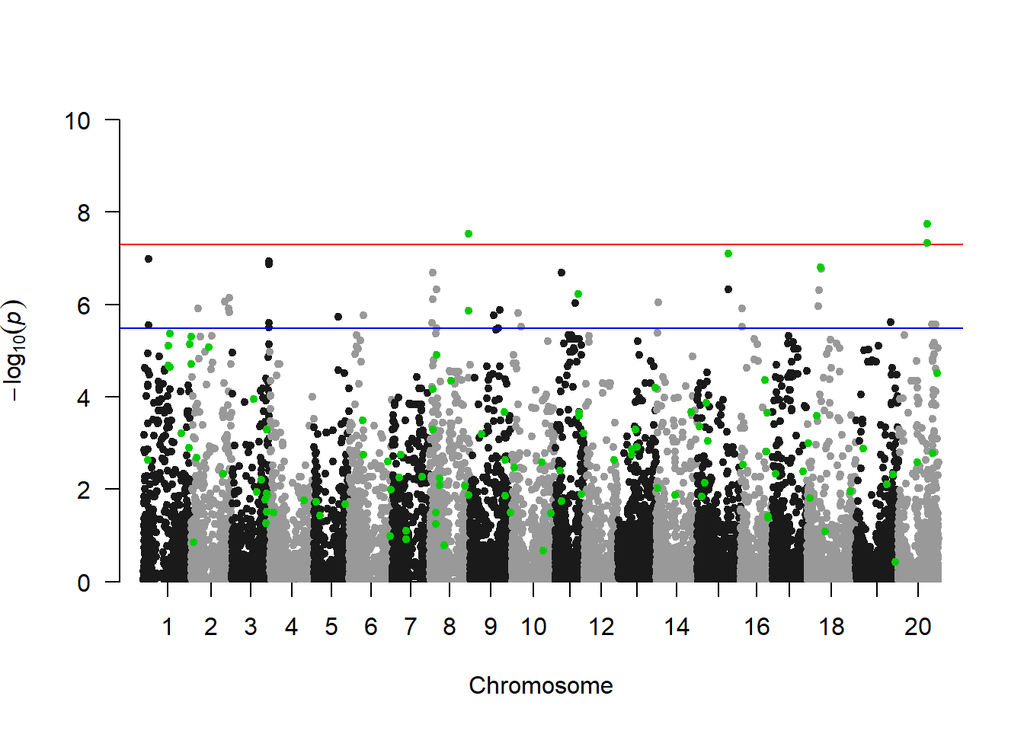

```r
nonzero.enet.opt <- which( fit.enet.opt.min$beta != 0 )
bonferroni.cutoff <- 0.05/ncol(x)
qqman::manhattan(df.lm.pvalue,
                 chr="CHR", bp="BP", p="P", snp="SNP",
                 suggestiveline=-log10(bonferroni.cutoff),
                 highlight=df.lm.pvalue[nonzero.enet.opt,"SNP"],
                 ylim=c(0,10))
```

## Penalty factors

- If we consider the variable known to be associated with response variable, we involve them as covariates in the model.

### Generating arbitrary covariates

```r
cov1 <- NULL
cov1[y2==0] <- rbinom(sum(y2==0), 1, prob=0.8)
cov1[y2==1] <- rbinom(sum(y2==1), 1, prob=0.4)
table(y2, cov1)
```

```
##    cov1
## y2    0   1
##   0  38 147
##   1 109  76
```

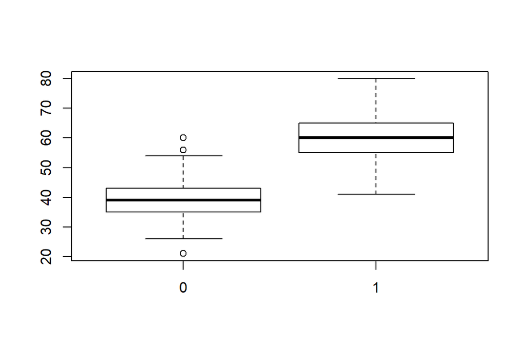

```r
cov2 <- NULL
cov2[y2==0] <- rpois(sum(y2==0), lambda=40)
cov2[y2==1] <- rpois(sum(y2==1), lambda=60)
boxplot(cov2~y2)
```

```r
x.cov <- cbind(cov1, cov2, x)

pf <- c(0, 0, rep(1,ncol(x)) )
table(pf)
```

```
## pf
##     0     1
##     2 15000
```

```r
pf.fit <- glmnet(x.cov, y2, family="binomial", penalty.factor = pf, nlambda=10 )
pf.fit
```

```
##
## Call:  glmnet(x = x.cov, y = y2, family = "binomial", nlambda = 10,      penalty.factor = pf)
##
##       Df   %Dev    Lambda
##  [1,]  2 0.7570 0.0532100
##  [2,] 23 0.8201 0.0319000
##  [3,] 54 0.9024 0.0191200
##  [4,] 62 0.9452 0.0114600
##  [5,] 67 0.9682 0.0068720
##  [6,] 75 0.9813 0.0041200
##  [7,] 82 0.9889 0.0024700
##  [8,] 82 0.9934 0.0014800
##  [9,] 84 0.9960 0.0008875
## [10,] 85 0.9976 0.0005321
```

```r
# save.image(file="part3.RData")
```